# 重賞レース予測レポート【レース終了】

作成日時: 2026/02/15 19:58:31

☞ [マニュアル(pdf)](https://ryutoro-galois.github.io/keiba-predictor/manual/manual.pdf)

☞ 過去6年の同一レース結果: [2025年](https://ryutoro-galois.github.io/keiba-predictor/report/PredResult_2025y_raceDate_20250215_20250216.html), [2024年](https://ryutoro-galois.github.io/keiba-predictor/report/PredResult_2024y_raceDate_20240210_20240211.html), [2023年](https://ryutoro-galois.github.io/keiba-predictor/report/PredResult_2023y_raceDate_20230211_20230212.html), [2022年](https://ryutoro-galois.github.io/keiba-predictor/report/PredResult_2022y_raceDate_20220212_20220213.html), [2021年](https://ryutoro-galois.github.io/keiba-predictor/report/PredResult_2021y_raceDate_20210213_20210214.html), [2020年](https://ryutoro-galois.github.io/keiba-predictor/report/PredResult_2020y_raceDate_20200215_20200216.html)

☞ 過去4週間の別レース結果: [1週前(2/8)](https://ryutoro-galois.github.io/keiba-predictor/report/PredResult_2026y_raceDate_20260208_20260208.html), [2週前(2/1)](https://ryutoro-galois.github.io/keiba-predictor/report/PredResult_2026y_raceDate_20260201_20260201.html), [3週前(1/24-25)](https://ryutoro-galois.github.io/keiba-predictor/report/PredResult_2026y_raceDate_20260124_20260125.html), [4週前(1/18)](https://ryutoro-galois.github.io/keiba-predictor/report/PredResult_2026y_raceDate_20260118_20260118.html)

☞ レース結果(csv): [2/14-15](https://ryutoro-galois.github.io/keiba-predictor/csv/race_result_20260214_20260215.csv)

## 【レース結果(1)】人気と着順の関係

### 【クイーンカップ(2026/02/14(土))】

【クイーンカップ(GⅢ)】  
2026/02/14(土), 05_東京, 芝左1600m

[interactive chart not shown]

### 【小倉ジャンプステークス(2026/02/14(土))】

【小倉ジャンプステークス(JGⅢ)】  
2026/02/14(土), 10_小倉, 障3390m

[interactive chart not shown]

### 【共同通信杯(2026/02/15(日))】

【共同通信杯(GⅢ)】  
2026/02/15(日), 05_東京, 芝左1800m

[interactive chart not shown]

### 【京都記念(2026/02/15(日))】

【京都記念(GⅡ)】  
2026/02/15(日), 08_京都, 芝右外2200m

[interactive chart not shown]

## 【レース結果(2)】コーナー通過順位

### 【クイーンカップ(2026/02/14(土))】

【クイーンカップ(GⅢ)】  
2026/02/14(土), 05_東京, 芝左1600m

[interactive chart not shown]

### 【小倉ジャンプステークス(2026/02/14(土))】

【小倉ジャンプステークス(JGⅢ)】  
2026/02/14(土), 10_小倉, 障3390m

[interactive chart not shown]

### 【共同通信杯(2026/02/15(日))】

【共同通信杯(GⅢ)】  
2026/02/15(日), 05_東京, 芝左1800m

[interactive chart not shown]

### 【京都記念(2026/02/15(日))】

【京都記念(GⅡ)】  
2026/02/15(日), 08_京都, 芝右外2200m

[interactive chart not shown]

## 0. 推し馬予測 (AI予測)

### 【クイーンカップ(GⅢ) 2026/02/14(土)】

- 本命(◎): 1-3着内確率(勝負強さ)が1位の馬
- 対抗(◯): 1-3着内確率が2-N位(20%程度以上)の中で予測タイムが最も速い馬
- 3番手(▲): 1-3着内確率が2-N位(20%程度以上)のでダークホース確率が最も高い馬
- 穴: ダークホース確率が上位1-M位(40%程度以上)の中で1-3着内確率が最も高い馬

| 推し馬 | 枠番 | 馬番 | 人気 | オッズ | 馬名 | 騎手 | 調教師 | 予測タイム(sec) | 1_順位 | 1-3着内確率(%) | 2_順位 | ﾀﾞｰｸﾎｰｽ確率(%) | 3_順位 |
| --- | --- | --- | --- | --- | --- | --- | --- | --- | --- | --- | --- | --- | --- |
| 本命(◎) | 1 | 1 | 2 | 3.4 | ドリームコア | Ｃ．ルメール | 萩原清 | 104.1 | 14 | 74.4 | 1 | 0.4 | 15 |
| 対抗(◯) | 2 | 4 | 3 | 9.8 | モートンアイランド | Ｒ．キング | 手塚貴久 | 97.0 | 5 | 38.3 | 2 | 0.7 | 13 |
| 3番手(▲) | 2 | 3 | 5 | 13.3 | マルガ | 武豊 | 須貝尚介 | 97.2 | 7 | 26.9 | 4 | 1.1 | 10 |
| 穴 | 1 | 2 | 11 | 31.0 | ジッピーチューン | 北村友一 | 林徹 | 98.9 | 11 | 15.6 | 9 | 47.3 | 1 |

### 【小倉ジャンプステークス(JGⅢ) 2026/02/14(土)】

- 本命(◎): 1-3着内確率(勝負強さ)が1位の馬
- 対抗(◯): 1-3着内確率が2-N位(20%程度以上)の中で予測タイムが最も速い馬
- 3番手(▲): 1-3着内確率が2-N位(20%程度以上)のでダークホース確率が最も高い馬
- 穴: ダークホース確率が上位1-M位(40%程度以上)の中で1-3着内確率が最も高い馬

| 推し馬 | 枠番 | 馬番 | 人気 | オッズ | 馬名 | 騎手 | 調教師 | 予測タイム(sec) | 1_順位 | 1-3着内確率(%) | 2_順位 | ﾀﾞｰｸﾎｰｽ確率(%) | 3_順位 |
| --- | --- | --- | --- | --- | --- | --- | --- | --- | --- | --- | --- | --- | --- |
| 本命(◎) | 2 | 2 | 3 | 8.6 | ローディアマント | 伴啓太 | 尾関知人 | 222.3 | 7.0 | 22.6 | 1 | 1.2 | 10 |
| 対抗(◯) | 1 | 1 | 1 | 1.3 | ジューンベロシティ | 高田潤 | 武英智 | 205.8 | 1.5 | 18.9 | 2 | 0.4 | 13 |
| 3番手(▲) | 7 | 11 | 6 | 35.9 | トーアモルペウス | 石神深一 | 辻哲英 | 222.6 | 9.0 | 10.5 | 5 | 2.0 | 7 |
| 穴 | 8 | 13 | 11 | 140.9 | トゥラッタッタ | 草野太郎 | 新開幸一 | 221.7 | 6.0 | 9.5 | 7 | 60.7 | 1 |

### 【共同通信杯(GⅢ) 2026/02/15(日)】

- 本命(◎): 1-3着内確率(勝負強さ)が1位の馬
- 対抗(◯): 1-3着内確率が2-N位(20%程度以上)の中で予測タイムが最も速い馬
- 3番手(▲): 1-3着内確率が2-N位(20%程度以上)のでダークホース確率が最も高い馬
- 穴: ダークホース確率が上位1-M位(40%程度以上)の中で1-3着内確率が最も高い馬

| 推し馬 | 枠番 | 馬番 | 人気 | オッズ | 馬名 | 騎手 | 調教師 | 予測タイム(sec) | 1_順位 | 1-3着内確率(%) | 2_順位 | ﾀﾞｰｸﾎｰｽ確率(%) | 3_順位 |
| --- | --- | --- | --- | --- | --- | --- | --- | --- | --- | --- | --- | --- | --- |
| 本命(◎) | 5 | 5 | 2 | 3.7 | リアライズシリウス | 津村明秀 | 手塚貴久 | 113.0 | 4.5 | 45.0 | 1 | 0.4 | 7.5 |
| 対抗(◯) | 6 | 6 | 3 | 4.2 | ロブチェン | 松山弘平 | 杉山晴紀 | 113.0 | 4.5 | 38.1 | 3 | 0.4 | 7.5 |
| 3番手(▲) | 4 | 4 | 5 | 8.4 | ディバインウインド | Ｒ．キング | 堀宣行 | 115.2 | 7.0 | 39.1 | 2 | 1.4 | 5.0 |
| 穴 | 3 | 3 | 8 | 96.6 | ガリレア | 石橋脩 | 清水英克 | 112.8 | 3.0 | 16.6 | 7 | 43.9 | 1.0 |

### 【京都記念(GⅡ) 2026/02/15(日)】

- 本命(◎): 1-3着内確率(勝負強さ)が1位の馬
- 対抗(◯): 1-3着内確率が2-N位(20%程度以上)の中で予測タイムが最も速い馬
- 3番手(▲): 1-3着内確率が2-N位(20%程度以上)のでダークホース確率が最も高い馬
- 穴: ダークホース確率が上位1-M位(40%程度以上)の中で1-3着内確率が最も高い馬

| 推し馬 | 枠番 | 馬番 | 人気 | オッズ | 馬名 | 騎手 | 調教師 | 予測タイム(sec) | 1_順位 | 1-3着内確率(%) | 2_順位 | ﾀﾞｰｸﾎｰｽ確率(%) | 3_順位 |
| --- | --- | --- | --- | --- | --- | --- | --- | --- | --- | --- | --- | --- | --- |
| 本命(◎) | 1 | 1 | 2 | 3.8 | ヘデントール | Ｃ．ルメール | 木村哲也 | 137.3 | 2 | 47.9 | 1 | 0.5 | 11 |
| 対抗(◯) | 5 | 6 | 1 | 1.8 | エリキング | 川田将雅 | 中内田充正 | 131.5 | 1 | 20.6 | 4 | 0.4 | 12 |
| 3番手(▲) | 2 | 2 | 4 | 9.7 | ヨーホーレイク | Ｔ．ハマーハンセン | 友道康夫 | 139.2 | 4 | 31.1 | 2 | 1.3 | 8 |
| 穴 | 3 | 3 | 7 | 27.9 | サフィラ | 西村淳也 | 池添学 | 143.6 | 5 | 11.1 | 6 | 59.5 | 2 |

## 1. 予測チャート (タイム/勝負強さ)

### 【クイーンカップ(GⅢ)】

2026/02/14(土), 05_東京, 芝左1600m

[interactive chart not shown]

### 【小倉ジャンプステークス(JGⅢ)】

2026/02/14(土), 10_小倉, 障3390m

[interactive chart not shown]

### 【共同通信杯(GⅢ)】

2026/02/15(日), 05_東京, 芝左1800m

[interactive chart not shown]

### 【京都記念(GⅡ)】

2026/02/15(日), 08_京都, 芝右外2200m

[interactive chart not shown]

## 2. オッズモニタリング (毎時)

### 【クイーンカップ】

[interactive chart not shown]

### 【小倉ジャンプステークス】

[interactive chart not shown]

### 【共同通信杯】

[interactive chart not shown]

### 【京都記念】

[interactive chart not shown]

## 3. 出馬表

### 【クイーンカップ 2026/02/14(土) 】

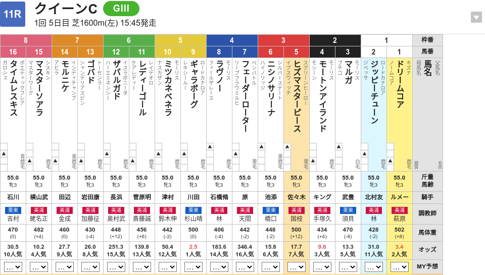

### 【小倉ジャンプステークス 2026/02/14(土) 】

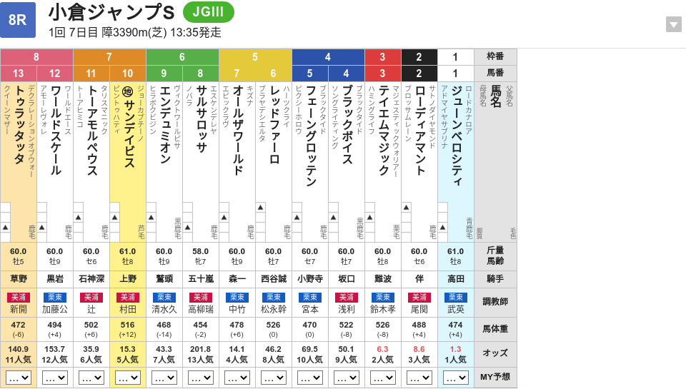

### 【共同通信杯 2026/02/15(日) 】

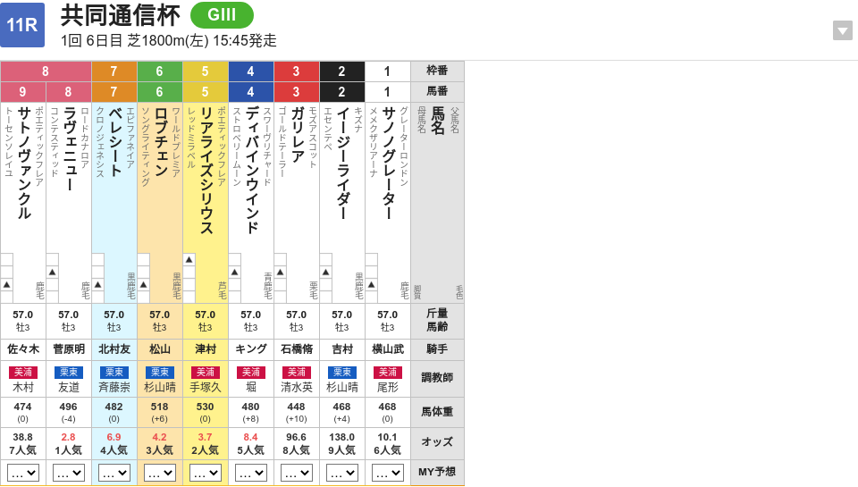

### 【京都記念 2026/02/15(日) 】

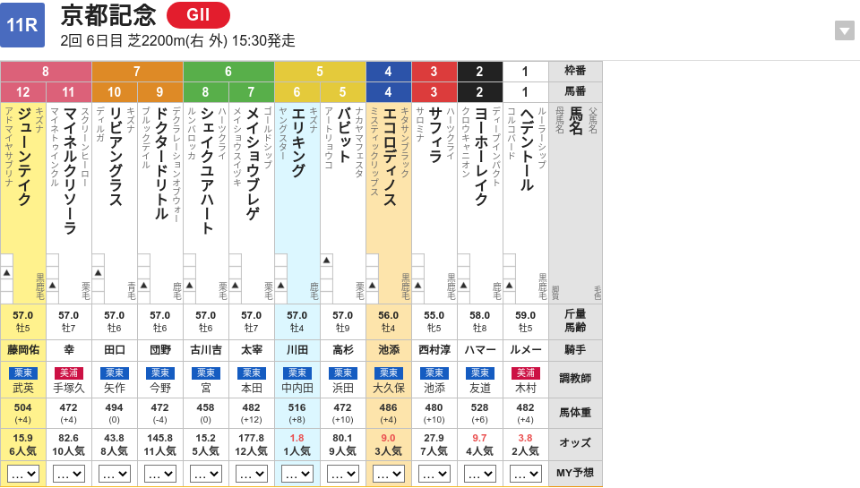

## 4. 単勝予測結果

### 【クイーンカップ(GⅢ) 2026/02/14(土)】

| 枠番 | 馬番 | 人気 | オッズ | 馬名 | 騎手 | 調教師 | 予測タイム(sec) | 1_順位 | 1-3着内確率(%) | 2_順位 | ﾀﾞｰｸﾎｰｽ確率(%) | 3_順位 |
| --- | --- | --- | --- | --- | --- | --- | --- | --- | --- | --- | --- | --- |
| 1 | 1 | 2 | 3.4 | ドリームコア | Ｃ．ルメール | 萩原清 | 104.1 | 14.0 | 74.4 | 1 | 0.4 | 15 |
| 1 | 2 | 11 | 31.0 | ジッピーチューン | 北村友一 | 林徹 | 98.9 | 11.0 | 15.6 | 9 | 47.3 | 1 |
| 2 | 3 | 5 | 13.3 | マルガ | 武豊 | 須貝尚介 | 97.2 | 7.0 | 26.9 | 4 | 1.1 | 10 |
| 2 | 4 | 3 | 9.8 | モートンアイランド | Ｒ．キング | 手塚貴久 | 97.0 | 5.0 | 38.3 | 2 | 0.7 | 13 |
| 3 | 5 | 7 | 17.7 | ヒズマスターピース | 佐々木大輔 | 国枝栄 | 97.3 | 9.0 | 22.3 | 6 | 1.1 | 11 |
| 3 | 6 | 6 | 15.8 | ニシノサリーナ | 池添謙一 | 橋口慎介 | 97.2 | 6.0 | 22.5 | 5 | 1.1 | 12 |
| 4 | 7 | 16 | 346.4 | フェーダーローター | 原優介 | 天間昭一 | 96.7 | 2.0 | 11.1 | 12 | 47.1 | 2 |
| 4 | 8 | 14 | 183.6 | ラヴノー | 石橋脩 | 林徹 | 100.7 | 13.0 | 10.8 | 13 | 45.6 | 3 |
| 5 | 9 | 1 | 2.5 | ギャラボーグ | 川田将雅 | 杉山晴紀 | 92.5 | 1.0 | 18.2 | 7 | 0.4 | 16 |
| 5 | 10 | 12 | 50.4 | ミツカネベネラ | 津村明秀 | 鈴木伸尋 | 96.9 | 3.5 | 10.5 | 14 | 37.0 | 4 |

[output cut: 6 more lines]

### 【小倉ジャンプステークス(JGⅢ) 2026/02/14(土)】

| 枠番 | 馬番 | 人気 | オッズ | 馬名 | 騎手 | 調教師 | 予測タイム(sec) | 1_順位 | 1-3着内確率(%) | 2_順位 | ﾀﾞｰｸﾎｰｽ確率(%) | 3_順位 |
| --- | --- | --- | --- | --- | --- | --- | --- | --- | --- | --- | --- | --- |
| 1 | 1 | 1 | 1.3 | ジューンベロシティ | 高田潤 | 武英智 | 205.8 | 1.5 | 18.9 | 2 | 0.4 | 13 |
| 2 | 2 | 3 | 8.6 | ローディアマント | 伴啓太 | 尾関知人 | 222.3 | 7.0 | 22.6 | 1 | 1.2 | 10 |
| 3 | 3 | 2 | 6.3 | テイエムマジック | 難波剛健 | 鈴木孝志 | 223.1 | 11.0 | 18.2 | 3 | 0.6 | 12 |
| 4 | 4 | 9 | 50.1 | ブラックボイス | 坂口智康 | 浅利英明 | 217.6 | 5.0 | 6.9 | 8 | 31.1 | 4 |
| 4 | 5 | 10 | 69.5 | フェーングロッテン | 小野寺祐太 | 宮本博 | 217.4 | 4.0 | 4.8 | 10 | 14.5 | 6 |
| 5 | 6 | 8 | 46.2 | レッドファーロ | 西谷誠 | 松永幹夫 | 205.8 | 1.5 | 4.9 | 9 | 44.2 | 2 |
| 5 | 7 | 4 | 14.1 | オールザワールド | 森一馬 | 中竹和也 | 222.5 | 8.0 | 14.4 | 4 | 1.0 | 11 |
| 6 | 8 | 13 | 201.8 | サルサロッサ | 五十嵐雄祐 | 高柳瑞樹 | 228.3 | 12.0 | 1.6 | 13 | 16.9 | 5 |
| 6 | 9 | 7 | 43.3 | エンデュミオン | 鷲頭虎太 | 清水久詞 | 215.5 | 3.0 | 4.7 | 11 | 1.5 | 9 |
| 7 | 10 | 5 | 15.3 | サンデイビス | 上野翔 | 村田一誠 | 228.6 | 13.0 | 10.3 | 6 | 1.6 | 8 |

[output cut: 3 more lines]

### 【共同通信杯(GⅢ) 2026/02/15(日)】

| 枠番 | 馬番 | 人気 | オッズ | 馬名 | 騎手 | 調教師 | 予測タイム(sec) | 1_順位 | 1-3着内確率(%) | 2_順位 | ﾀﾞｰｸﾎｰｽ確率(%) | 3_順位 |
| --- | --- | --- | --- | --- | --- | --- | --- | --- | --- | --- | --- | --- |
| 1 | 1 | 6 | 10.1 | サノノグレーター | 横山武史 | 尾形和幸 | 113.5 | 6.0 | 17.7 | 6 | 34.9 | 3.0 |
| 2 | 2 | 9 | 138.0 | イージーライダー | 吉村誠之助 | 杉山晴紀 | 119.9 | 8.0 | 3.4 | 9 | 11.7 | 4.0 |
| 3 | 3 | 8 | 96.6 | ガリレア | 石橋脩 | 清水英克 | 112.8 | 3.0 | 16.6 | 7 | 43.9 | 1.0 |
| 4 | 4 | 5 | 8.4 | ディバインウインド | Ｒ．キング | 堀宣行 | 115.2 | 7.0 | 39.1 | 2 | 1.4 | 5.0 |
| 5 | 5 | 2 | 3.7 | リアライズシリウス | 津村明秀 | 手塚貴久 | 113.0 | 4.5 | 45.0 | 1 | 0.4 | 7.5 |
| 6 | 6 | 3 | 4.2 | ロブチェン | 松山弘平 | 杉山晴紀 | 113.0 | 4.5 | 38.1 | 3 | 0.4 | 7.5 |
| 7 | 7 | 4 | 6.9 | ベレシート | 北村友一 | 斉藤崇史 | 121.5 | 9.0 | 28.0 | 4 | 1.0 | 6.0 |
| 8 | 8 | 1 | 2.8 | ラヴェニュー | 菅原明良 | 友道康夫 | 106.0 | 1.0 | 18.2 | 5 | 0.4 | 9.0 |
| 8 | 9 | 7 | 38.8 | サトノヴァンクル | 佐々木大輔 | 木村哲也 | 112.5 | 2.0 | 10.1 | 8 | 39.3 | 2.0 |

### 【京都記念(GⅡ) 2026/02/15(日)】

| 枠番 | 馬番 | 人気 | オッズ | 馬名 | 騎手 | 調教師 | 予測タイム(sec) | 1_順位 | 1-3着内確率(%) | 2_順位 | ﾀﾞｰｸﾎｰｽ確率(%) | 3_順位 |
| --- | --- | --- | --- | --- | --- | --- | --- | --- | --- | --- | --- | --- |
| 1 | 1 | 2 | 3.8 | ヘデントール | Ｃ．ルメール | 木村哲也 | 137.3 | 2.0 | 47.9 | 1 | 0.5 | 11 |
| 2 | 2 | 4 | 9.7 | ヨーホーレイク | Ｔ．ハマーハンセン | 友道康夫 | 139.2 | 4.0 | 31.1 | 2 | 1.3 | 8 |
| 3 | 3 | 7 | 27.9 | サフィラ | 西村淳也 | 池添学 | 143.6 | 5.0 | 11.1 | 6 | 59.5 | 2 |
| 4 | 4 | 3 | 9.0 | エコロディノス | 池添謙一 | 大久保龍志 | 144.6 | 8.0 | 25.2 | 3 | 1.1 | 9 |
| 5 | 5 | 9 | 80.1 | バビット | 高杉吏麒 | 浜田多実雄 | 138.4 | 3.0 | 4.1 | 10 | 15.7 | 5 |
| 5 | 6 | 1 | 1.8 | エリキング | 川田将雅 | 中内田充正 | 131.5 | 1.0 | 20.6 | 4 | 0.4 | 12 |
| 6 | 7 | 12 | 177.8 | メイショウブレゲ | 太宰啓介 | 本田優 | 144.5 | 7.0 | 2.8 | 12 | 11.4 | 6 |
| 6 | 8 | 5 | 15.2 | シェイクユアハート | 古川吉洋 | 宮徹 | 145.3 | 11.0 | 8.6 | 7 | 1.0 | 10 |
| 7 | 9 | 11 | 145.8 | ドクタードリトル | 団野大成 | 今野貞一 | 144.9 | 9.5 | 4.6 | 9 | 57.9 | 3 |
| 7 | 10 | 8 | 43.8 | リビアングラス | 田口貫太 | 矢作芳人 | 144.9 | 9.5 | 5.0 | 8 | 47.6 | 4 |

[output cut: 2 more lines]

## 5. 人気と着順の乖離率推移

### 【クイーンカップ_1990y_2019y】

[interactive chart not shown]

### 【共同通信杯_1990y_2019y】

[interactive chart not shown]

### 【京都記念_1990y_2019y】

[interactive chart not shown]

### 【クイーンカップ_1990y_2019y】

| No | 開催年 | 不整合率(%) | 頭数 | 人気別着順(1-3位) | 人気別着順(全体) |
| --- | --- | --- | --- | --- | --- |
| 30 | 2019 | 40.9 | 14頭 | 1-5-9 | 1\|5\|9\|4\|8\|3\|2\|7\|12\|10\|14\|13\|11\|6 |
| 29 | 2018 | 27.3 | 11頭 | 1-4-2 | 1\|4\|2\|7\|9\|8\|6\|10\|5\|3\|11 |
| 28 | 2017 | 36.9 | 13頭 | 2-6-8 | 2\|6\|8\|5\|10\|1\|3\|12\|7\|4\|13\|11\|9 |
| 27 | 2016 | 33.1 | 13頭 | 9-1-11 | 9\|1\|11\|8\|5\|6\|10\|2\|4\|3\|13\|7\|12 |
| 26 | 2015 | 47.3 | 10頭 | 7-1-4 | 7\|1\|4\|6\|5\|8\|3\|2\|9\|10 |
| 25 | 2014 | 25.6 | 14頭 | 2-6-1 | 2\|6\|1\|9\|3\|8\|4\|13\|5\|11\|7\|14\|10\|12 |
| 24 | 2013 | 21.0 | 8頭 | 1-8-3 | 1\|8\|3\|2\|4\|6\|7\|5 |
| 23 | 2012 | 31.2 | 14頭 | 1-10-4 | 1\|10\|4\|3\|2\|14\|8\|5\|13\|7\|9\|11\|12\|6 |
| 22 | 2011 | 29.3 | 14頭 | 1-10-3 | 1\|10\|3\|6\|4\|2\|5\|14\|12\|13\|11\|8\|9\|7 |
| 21 | 2010 | 46.5 | 14頭 | 2-3-6 | 2\|3\|6\|7\|5\|11\|4\|1\|9\|10\|13\|8\|12\|14 |

[output cut: 20 more lines]

### 【共同通信杯_1990y_2019y】

| No | 開催年 | 不整合率(%) | 頭数 | 人気別着順(1-3位) | 人気別着順(全体) |
| --- | --- | --- | --- | --- | --- |
| 29 | 2019 | 42.8 | 7頭 | 3-1-4 | 3\|1\|4\|2\|5\|7\|6 |
| 28 | 2018 | 59.0 | 12頭 | 6-3-10 | 6\|3\|10\|4\|7\|8\|1\|9\|5\|2\|12\|11 |
| 27 | 2017 | 30.3 | 11頭 | 2-6-1 | 2\|6\|1\|4\|9\|3\|8\|5\|7\|10\|11 |
| 26 | 2016 | 81.0 | 10頭 | 6-5-3 | 6\|5\|3\|4\|9\|2\|7\|8\|1\|10 |
| 25 | 2015 | 38.8 | 12頭 | 3-1-4 | 3\|1\|4\|8\|2\|6\|7\|10\|9\|11\|12\|5 |
| 24 | 2014 | 26.7 | 14頭 | 1-3-2 | 1\|3\|2\|7\|6\|9\|8\|5\|13\|11\|10\|4\|12\|14 |
| 23 | 2013 | 39.6 | 10頭 | 4-2-9 | 4\|2\|9\|1\|3\|10\|8\|6\|5\|7 |
| 22 | 2012 | 16.3 | 11頭 | 2-1-3 | 2\|1\|3\|4\|7\|5\|6\|10\|8\|11\|9 |
| 21 | 2011 | 63.8 | 13頭 | 3-6-5 | 3\|6\|5\|2\|11\|4\|12\|10\|1\|13\|8\|9\|7 |
| 20 | 2010 | 44.3 | 13頭 | 3-2-1 | 3\|2\|1\|4\|9\|6\|13\|8\|12\|7\|5\|10\|11 |

[output cut: 19 more lines]

### 【京都記念_1990y_2019y】

| No | 開催年 | 不整合率(%) | 頭数 | 人気別着順(1-3位) | 人気別着順(全体) |
| --- | --- | --- | --- | --- | --- |
| 30 | 2019 | 24.0 | 12頭 | 6-1-2 | 6\|1\|2\|4\|9\|7\|11\|5\|3\|10\|8\|12 |
| 29 | 2018 | 51.6 | 10頭 | 4-3-1 | 4\|3\|1\|2\|9\|6\|7\|5\|10\|8 |
| 28 | 2017 | 42.4 | 10頭 | 3-5-1 | 3\|5\|1\|2\|8\|6\|4\|10\|7\|9 |
| 27 | 2016 | 64.3 | 15頭 | 6-3-4 | 6\|3\|4\|10\|2\|5\|12\|9\|8\|14\|11\|1\|13\|7\|15 |
| 26 | 2015 | 55.9 | 11頭 | 3-4-2 | 3\|4\|2\|7\|1\|5\|6\|9\|8\|10\|11 |
| 25 | 2014 | 51.1 | 12頭 | 6-2-4 | 6\|2\|4\|3\|5\|1\|8\|7\|11\|10\|9\|12 |
| 24 | 2013 | 56.4 | 11頭 | 6-3-2 | 6\|3\|2\|5\|1\|4\|7\|8\|10\|11\|9 |
| 23 | 2012 | 38.4 | 9頭 | 5-1-3 | 5\|1\|3\|4\|7\|2\|9\|8\|6 |
| 22 | 2011 | 13.8 | 12頭 | 1-5-2 | 1\|5\|2\|3\|7\|6\|4\|8\|9\|10\|11\|12 |
| 21 | 2010 | 23.7 | 13頭 | 1-3-2 | 1\|3\|2\|6\|13\|9\|5\|7\|10\|4\|8\|12\|11 |

[output cut: 20 more lines]

## 6. 1-3番人気馬の着順分類予測

### 【クイーンカップ】

| 分類 | 凡例 | 発生確率(%) | 当該レース | 当該レースランク | 直近1年間 |
| --- | --- | --- | --- | --- | --- |
| 1: 1番人気のみ (1_pop1) | 1 \| * \| * | 19.1 | 0.53 | 0.75 | 0.57 |
| 4: 1,2番人気のみ (4_pop12) | 1 \| 2 \| * | 15.7 | 0.63 | 0.80 | 0.47 |
| 8: 1,2,3番人気すべて着外 (8_darkhorse) | * \| * \| * | 15.6 | 5.57 | 3.71 | 0.00 |
| 5: 1,3番人気のみ (5_pop13) | 1 \| 3 \| * | 13.2 | 1.19 | 0.59 | 0.40 |
| 3: 3番人気のみ (3_pop3) | 3 \| * \| * | 10.7 | 1.29 | 0.95 | 0.00 |
| 6: 2,3番人気のみ (6_pop23) | 2 \| 3 \| * | 9.5 | 1.14 | 2.26 | 0.00 |
| 2: 2番人気のみ (2_pop2) | 2 \| * \| * | 9.0 | 1.08 | 1.61 | 0.00 |
| 7: 1,2,3番人気すべて着内 (7_pop123) | 1 \| 2 \| 3 | 7.3 | 0.00 | 1.04 | 0.00 |

### 【共同通信杯】

| 分類 | 凡例 | 発生確率(%) | 当該レース | 当該レースランク | 直近1年間 |
| --- | --- | --- | --- | --- | --- |
| 1: 1番人気のみ (1_pop1) | 1 \| * \| * | 19.1 | 1.34 | 1.34 | 0.00 |
| 4: 1,2番人気のみ (4_pop12) | 1 \| 2 \| * | 15.7 | 1.10 | 1.10 | 0.31 |
| 8: 1,2,3番人気すべて着外 (8_darkhorse) | * \| * \| * | 15.6 | 2.74 | 2.74 | 0.00 |
| 5: 1,3番人気のみ (5_pop13) | 1 \| 3 \| * | 13.2 | 0.38 | 0.38 | 0.26 |
| 3: 3番人気のみ (3_pop3) | 3 \| * \| * | 10.7 | 0.75 | 0.75 | 0.00 |
| 6: 2,3番人気のみ (6_pop23) | 2 \| 3 \| * | 9.5 | 0.00 | 0.00 | 0.00 |
| 2: 2番人気のみ (2_pop2) | 2 \| * \| * | 9.0 | 3.10 | 3.10 | 0.00 |
| 7: 1,2,3番人気すべて着内 (7_pop123) | 1 \| 2 \| 3 | 7.3 | 0.51 | 0.51 | 0.00 |

### 【京都記念】

| 分類 | 凡例 | 発生確率(%) | 当該レース | 当該レースランク | 直近1年間 |
| --- | --- | --- | --- | --- | --- |
| 5: 1,3番人気のみ (5_pop13) | 1 \| 3 \| * | 18.5 | 1.11 | 1.11 | 0.37 |
| 1: 1番人気のみ (1_pop1) | 1 \| * \| * | 16.3 | 2.91 | 2.91 | 0.00 |
| 4: 1,2番人気のみ (4_pop12) | 1 \| 2 \| * | 15.2 | 0.50 | 0.50 | 0.30 |
| 8: 1,2,3番人気すべて着外 (8_darkhorse) | * \| * \| * | 15.0 | 1.81 | 1.81 | 0.00 |
| 3: 3番人気のみ (3_pop3) | 3 \| * \| * | 10.3 | 1.24 | 1.24 | 0.00 |
| 6: 2,3番人気のみ (6_pop23) | 2 \| 3 \| * | 9.2 | 1.11 | 1.11 | 0.00 |
| 2: 2番人気のみ (2_pop2) | 2 \| * \| * | 8.6 | 1.04 | 1.04 | 0.00 |
| 7: 1,2,3番人気すべて着内 (7_pop123) | 1 \| 2 \| 3 | 7.0 | 0.50 | 0.50 | 0.00 |

## 7. 3連複予測結果

### 【クイーンカップ(GⅢ) 2026/02/14(土)】

| 分類 | 馬番 | 枠番 | 人気 | 平均予測タイム(sec) | 1-3着内確率(%) | ﾀﾞｰｸﾎｰｽ確率(%) | 馬名 | 騎手 | 調教師 |
| --- | --- | --- | --- | --- | --- | --- | --- | --- | --- |
| 6: 2,3番人気のみ (6_pop23) | 1-4-15 | 1-2-8 | 2-3-4 | 99.43 | 8.02 | 0.00 | ドリームコア \| モートンアイランド \| マスターソアラ | Ｃ．ルメール \| Ｒ．キング \| 横山武史 | 萩原清 \| 手塚貴久 \| 蛯名正義 |
| 6: 2,3番人気のみ (6_pop23) | 1-4-3 | 1-2-2 | 2-3-5 | 99.43 | 7.67 | 0.00 | ドリームコア \| モートンアイランド \| マルガ | Ｃ．ルメール \| Ｒ．キング \| 武豊 | 萩原清 \| 手塚貴久 \| 須貝尚介 |
| 6: 2,3番人気のみ (6_pop23) | 1-4-6 | 1-2-3 | 2-3-6 | 99.43 | 6.41 | 0.00 | ドリームコア \| モートンアイランド \| ニシノサリーナ | Ｃ．ルメール \| Ｒ．キング \| 池添謙一 | 萩原清 \| 手塚貴久 \| 橋口慎介 |
| 6: 2,3番人気のみ (6_pop23) | 1-4-5 | 1-2-3 | 2-3-7 | 99.47 | 6.35 | 0.00 | ドリームコア \| モートンアイランド \| ヒズマスターピース | Ｃ．ルメール \| Ｒ．キング \| 佐々木大輔 | 萩原清 \| 手塚貴久 \| 国枝栄 |
| 2: 2番人気のみ (2_pop2) | 1-15-3 | 1-8-2 | 2-4-5 | 99.50 | 5.64 | 0.00 | ドリームコア \| マスターソアラ \| マルガ | Ｃ．ルメール \| 横山武史 \| 武豊 | 萩原清 \| 蛯名正義 \| 須貝尚介 |
| 7: 1,2,3番人気すべて着内 (7_pop123) | 9-1-4 | 5-1-2 | 1-2-3 | 97.87 | 5.19 | 0.00 | ギャラボーグ \| ドリームコア \| モートンアイランド | 川田将雅 \| Ｃ．ルメール \| Ｒ．キング | 杉山晴紀 \| 萩原清 \| 手塚貴久 |
| 2: 2番人気のみ (2_pop2) | 1-15-6 | 1-8-3 | 2-4-6 | 99.50 | 4.72 | 0.00 | ドリームコア \| マスターソアラ \| ニシノサリーナ | Ｃ．ルメール \| 横山武史 \| 池添謙一 | 萩原清 \| 蛯名正義 \| 橋口慎介 |
| 2: 2番人気のみ (2_pop2) | 1-15-5 | 1-8-3 | 2-4-7 | 99.53 | 4.67 | 0.00 | ドリームコア \| マスターソアラ \| ヒズマスターピース | Ｃ．ルメール \| 横山武史 \| 佐々木大輔 | 萩原清 \| 蛯名正義 \| 国枝栄 |
| 2: 2番人気のみ (2_pop2) | 1-3-6 | 1-2-3 | 2-5-6 | 99.50 | 4.50 | 0.00 | ドリームコア \| マルガ \| ニシノサリーナ | Ｃ．ルメール \| 武豊 \| 池添謙一 | 萩原清 \| 須貝尚介 \| 橋口慎介 |
| 6: 2,3番人気のみ (6_pop23) | 1-4-13 | 1-2-7 | 2-3-8 | 100.03 | 4.47 | 0.00 | ドリームコア \| モートンアイランド \| ゴバド | Ｃ．ルメール \| Ｒ．キング \| 岩田康誠 | 萩原清 \| 手塚貴久 \| 加藤征弘 |

[output cut: 550 more lines]

### 【小倉ジャンプステークス(JGⅢ) 2026/02/14(土)】

| 分類 | 馬番 | 枠番 | 人気 | 平均予測タイム(sec) | 1-3着内確率(%) | ﾀﾞｰｸﾎｰｽ確率(%) | 馬名 | 騎手 | 調教師 |
| --- | --- | --- | --- | --- | --- | --- | --- | --- | --- |
| 7: 1,2,3番人気すべて着内 (7_pop123) | 1-3-2 | 1-3-2 | 1-2-3 | 217.07 | 0.78 | 0.00 | ジューンベロシティ \| テイエムマジック \| ローディアマント | 高田潤 \| 難波剛健 \| 伴啓太 | 武英智 \| 鈴木孝志 \| 尾関知人 |
| 5: 1,3番人気のみ (5_pop13) | 1-2-7 | 1-2-5 | 1-3-4 | 216.87 | 0.62 | 0.00 | ジューンベロシティ \| ローディアマント \| オールザワールド | 高田潤 \| 伴啓太 \| 森一馬 | 武英智 \| 尾関知人 \| 中竹和也 |
| 6: 2,3番人気のみ (6_pop23) | 3-2-7 | 3-2-5 | 2-3-4 | 222.63 | 0.59 | 0.00 | テイエムマジック \| ローディアマント \| オールザワールド | 難波剛健 \| 伴啓太 \| 森一馬 | 鈴木孝志 \| 尾関知人 \| 中竹和也 |
| 4: 1,2番人気のみ (4_pop12) | 1-3-7 | 1-3-5 | 1-2-4 | 217.13 | 0.49 | 0.00 | ジューンベロシティ \| テイエムマジック \| オールザワールド | 高田潤 \| 難波剛健 \| 森一馬 | 武英智 \| 鈴木孝志 \| 中竹和也 |
| 5: 1,3番人気のみ (5_pop13) | 1-2-11 | 1-2-7 | 1-3-6 | 216.90 | 0.45 | 0.00 | ジューンベロシティ \| ローディアマント \| トーアモルペウス | 高田潤 \| 伴啓太 \| 石神深一 | 武英智 \| 尾関知人 \| 辻哲英 |
| 5: 1,3番人気のみ (5_pop13) | 1-2-10 | 1-2-7 | 1-3-5 | 218.90 | 0.44 | 0.00 | ジューンベロシティ \| ローディアマント \| サンデイビス | 高田潤 \| 伴啓太 \| 上野翔 | 武英智 \| 尾関知人 \| 村田一誠 |
| 6: 2,3番人気のみ (6_pop23) | 3-2-11 | 3-2-7 | 2-3-6 | 222.67 | 0.43 | 0.00 | テイエムマジック \| ローディアマント \| トーアモルペウス | 難波剛健 \| 伴啓太 \| 石神深一 | 鈴木孝志 \| 尾関知人 \| 辻哲英 |
| 6: 2,3番人気のみ (6_pop23) | 3-2-10 | 3-2-7 | 2-3-5 | 224.67 | 0.42 | 0.00 | テイエムマジック \| ローディアマント \| サンデイビス | 難波剛健 \| 伴啓太 \| 上野翔 | 鈴木孝志 \| 尾関知人 \| 村田一誠 |
| 5: 1,3番人気のみ (5_pop13) | 1-2-13 | 1-2-8 | 1-3-11 | 216.60 | 0.41 | 0.00 | ジューンベロシティ \| ローディアマント \| トゥラッタッタ | 高田潤 \| 伴啓太 \| 草野太郎 | 武英智 \| 尾関知人 \| 新開幸一 |
| 6: 2,3番人気のみ (6_pop23) | 3-2-13 | 3-2-8 | 2-3-11 | 222.37 | 0.39 | 0.00 | テイエムマジック \| ローディアマント \| トゥラッタッタ | 難波剛健 \| 伴啓太 \| 草野太郎 | 鈴木孝志 \| 尾関知人 \| 新開幸一 |

[output cut: 276 more lines]

### 【共同通信杯(GⅢ) 2026/02/15(日)】

| 分類 | 馬番 | 枠番 | 人気 | 平均予測タイム(sec) | 1-3着内確率(%) | ﾀﾞｰｸﾎｰｽ確率(%) | 馬名 | 騎手 | 調教師 |
| --- | --- | --- | --- | --- | --- | --- | --- | --- | --- |
| 6: 2,3番人気のみ (6_pop23) | 5-6-4 | 5-6-4 | 2-3-5 | 113.73 | 6.69 | 0.00 | リアライズシリウス \| ロブチェン \| ディバインウインド | 津村明秀 \| 松山弘平 \| Ｒ．キング | 手塚貴久 \| 杉山晴紀 \| 堀宣行 |
| 2: 2番人気のみ (2_pop2) | 5-7-4 | 5-7-4 | 2-4-5 | 116.57 | 4.93 | 0.00 | リアライズシリウス \| ベレシート \| ディバインウインド | 津村明秀 \| 北村友一 \| Ｒ．キング | 手塚貴久 \| 斉藤崇史 \| 堀宣行 |
| 6: 2,3番人気のみ (6_pop23) | 5-6-7 | 5-6-7 | 2-3-4 | 115.83 | 4.80 | 0.00 | リアライズシリウス \| ロブチェン \| ベレシート | 津村明秀 \| 松山弘平 \| 北村友一 | 手塚貴久 \| 杉山晴紀 \| 斉藤崇史 |
| 3: 3番人気のみ (3_pop3) | 6-7-4 | 6-7-4 | 3-4-5 | 116.57 | 4.17 | 0.00 | ロブチェン \| ベレシート \| ディバインウインド | 松山弘平 \| 北村友一 \| Ｒ．キング | 杉山晴紀 \| 斉藤崇史 \| 堀宣行 |
| 4: 1,2番人気のみ (4_pop12) | 8-5-4 | 8-5-4 | 1-2-5 | 111.40 | 3.20 | 0.00 | ラヴェニュー \| リアライズシリウス \| ディバインウインド | 菅原明良 \| 津村明秀 \| Ｒ．キング | 友道康夫 \| 手塚貴久 \| 堀宣行 |
| 7: 1,2,3番人気すべて着内 (7_pop123) | 8-5-6 | 8-5-6 | 1-2-3 | 110.67 | 3.12 | 0.00 | ラヴェニュー \| リアライズシリウス \| ロブチェン | 菅原明良 \| 津村明秀 \| 松山弘平 | 友道康夫 \| 手塚貴久 \| 杉山晴紀 |
| 2: 2番人気のみ (2_pop2) | 5-4-1 | 5-4-1 | 2-5-6 | 113.90 | 3.11 | 0.00 | リアライズシリウス \| ディバインウインド \| サノノグレーター | 津村明秀 \| Ｒ．キング \| 横山武史 | 手塚貴久 \| 堀宣行 \| 尾形和幸 |
| 6: 2,3番人気のみ (6_pop23) | 5-6-1 | 5-6-1 | 2-3-6 | 113.17 | 3.03 | 0.00 | リアライズシリウス \| ロブチェン \| サノノグレーター | 津村明秀 \| 松山弘平 \| 横山武史 | 手塚貴久 \| 杉山晴紀 \| 尾形和幸 |
| 2: 2番人気のみ (2_pop2) | 5-4-3 | 5-4-3 | 2-5-8 | 113.67 | 2.92 | 0.00 | リアライズシリウス \| ディバインウインド \| ガリレア | 津村明秀 \| Ｒ．キング \| 石橋脩 | 手塚貴久 \| 堀宣行 \| 清水英克 |
| 6: 2,3番人気のみ (6_pop23) | 5-6-3 | 5-6-3 | 2-3-8 | 112.93 | 2.84 | 0.00 | リアライズシリウス \| ロブチェン \| ガリレア | 津村明秀 \| 松山弘平 \| 石橋脩 | 手塚貴久 \| 杉山晴紀 \| 清水英克 |

[output cut: 74 more lines]

### 【京都記念(GⅡ) 2026/02/15(日)】

| 分類 | 馬番 | 枠番 | 人気 | 平均予測タイム(sec) | 1-3着内確率(%) | ﾀﾞｰｸﾎｰｽ確率(%) | 馬名 | 騎手 | 調教師 |
| --- | --- | --- | --- | --- | --- | --- | --- | --- | --- |
| 6: 2,3番人気のみ (6_pop23) | 1-4-2 | 1-4-2 | 2-3-4 | 140.37 | 3.76 | 0.00 | ヘデントール \| エコロディノス \| ヨーホーレイク | Ｃ．ルメール \| 池添謙一 \| Ｔ．ハマーハンセン | 木村哲也 \| 大久保龍志 \| 友道康夫 |
| 4: 1,2番人気のみ (4_pop12) | 6-1-2 | 5-1-2 | 1-2-4 | 136.00 | 3.07 | 0.00 | エリキング \| ヘデントール \| ヨーホーレイク | 川田将雅 \| Ｃ．ルメール \| Ｔ．ハマーハンセン | 中内田充正 \| 木村哲也 \| 友道康夫 |
| 7: 1,2,3番人気すべて着内 (7_pop123) | 6-1-4 | 5-1-4 | 1-2-3 | 137.80 | 2.49 | 0.00 | エリキング \| ヘデントール \| エコロディノス | 川田将雅 \| Ｃ．ルメール \| 池添謙一 | 中内田充正 \| 木村哲也 \| 大久保龍志 |
| 2: 2番人気のみ (2_pop2) | 1-2-12 | 1-2-8 | 2-4-6 | 140.33 | 2.10 | 0.00 | ヘデントール \| ヨーホーレイク \| ジューンテイク | Ｃ．ルメール \| Ｔ．ハマーハンセン \| 藤岡佑介 | 木村哲也 \| 友道康夫 \| 武英智 |
| 6: 2,3番人気のみ (6_pop23) | 1-4-12 | 1-4-8 | 2-3-6 | 142.13 | 1.70 | 0.00 | ヘデントール \| エコロディノス \| ジューンテイク | Ｃ．ルメール \| 池添謙一 \| 藤岡佑介 | 木村哲也 \| 大久保龍志 \| 武英智 |
| 2: 2番人気のみ (2_pop2) | 1-2-3 | 1-2-3 | 2-4-7 | 140.03 | 1.65 | 0.00 | ヘデントール \| ヨーホーレイク \| サフィラ | Ｃ．ルメール \| Ｔ．ハマーハンセン \| 西村淳也 | 木村哲也 \| 友道康夫 \| 池添学 |
| 5: 1,3番人気のみ (5_pop13) | 6-4-2 | 5-4-2 | 1-3-4 | 138.43 | 1.61 | 0.00 | エリキング \| エコロディノス \| ヨーホーレイク | 川田将雅 \| 池添謙一 \| Ｔ．ハマーハンセン | 中内田充正 \| 大久保龍志 \| 友道康夫 |
| 4: 1,2番人気のみ (4_pop12) | 6-1-12 | 5-1-8 | 1-2-6 | 137.77 | 1.39 | 0.00 | エリキング \| ヘデントール \| ジューンテイク | 川田将雅 \| Ｃ．ルメール \| 藤岡佑介 | 中内田充正 \| 木村哲也 \| 武英智 |
| 6: 2,3番人気のみ (6_pop23) | 1-4-3 | 1-4-3 | 2-3-7 | 141.83 | 1.34 | 0.00 | ヘデントール \| エコロディノス \| サフィラ | Ｃ．ルメール \| 池添謙一 \| 西村淳也 | 木村哲也 \| 大久保龍志 \| 池添学 |
| 2: 2番人気のみ (2_pop2) | 1-2-8 | 1-2-6 | 2-4-5 | 140.60 | 1.28 | 0.00 | ヘデントール \| ヨーホーレイク \| シェイクユアハート | Ｃ．ルメール \| Ｔ．ハマーハンセン \| 古川吉洋 | 木村哲也 \| 友道康夫 \| 宮徹 |

[output cut: 210 more lines]

## 8. 直近の全レース情報

[output not shown]

[output cut: 9 more lines]